# **Analysis of Serbian News Channel Reports on Serbian Protests**

https://github.com/sarakojic/SOSC_314_Course_Project

## Introduction

This project focuses on the analysis of media reports on the ongoing student protests in Serbia which started in November 2024.

Serbian protests have been frequently mentioned in media including both social media platforms and news. However, the information presented on different social media platforms and news channels was highly conflicting. It is already known that in Serbia different news channels often present mutually contradicting narratives (Kleut). This brings the question how the different news channels were reporting on the most recent protests

[figure not shown]

*Figure 1: Novi Sad Railway Station, Photo by Sara Kojic*

## Problem setup

The goal of this projet is to analyze the way in which two different news chnannnels in Serbia report on the protests.

The two news channnels chosen for comparison are N1 [https://n1info.rs/] and RTS [https://www.rts.rs/lat.html?print=true].

The reason I chose these two news channels specifically is because N1 is usually considered as the only independent news source in Serbia, while RTS is a government-ran news channel

### Project tasks

1. analyze common words used by RTS and N1
2. compare the frequency of the published articles related to the protest over months
3. analyze different event types and their occurances over months in the news articles published by RTS and N1

## Data

Data I used in this project was collected by web scraping N1 and RTS websites and collecting all of the published articles published in the period starting from November 2024 to the end of December 2025.

I collected this data by directly webscraping HTML files of the two websites and collecting the headlines, link of the article, and date of publishing.

To webscrape articles from RTS I retreived html from https://www.rts.rs/lat/vesti/politika.html?position=1 by using requests. These rts urls contain the list of all RTS articles published in the segment news/politics. To change the page I was scraping from I just changed the position parameter of the url.

To webscrape articles from N1 I retreived html from https://n1info.rs/vesti/2/ by using requests. These N1 urls contain the list of all N1 articles published in the segment news. To change the page I was scraping from I just changed the page number in the url https://n1info.rs/vesti/PageNumber/

After collecting all of the articles published in the timeframe from November 2024-December 2025 I ended up with around 3 400 articles from RTS and 39500 articles from N1.

One of the factors that influences the discrepancy between the number of published articles by the two news channels is that the data I collected from RTS was already sorted into the news/politics category while N1 does not have news subsections so the data I used was classified as news. Nevertheless, N1 publishes more articles in comparison to RTS.

- 3400 RTS articles
- 39500 N1 articles

*(before data cleaning)*

The features I used in my dataset were

- headline - *article title/headline*
- url - *article url*
- datePublished - *exact time when the article was published*

## Data Cleaning

### Removing articles published outside of the November 2024- December 2025 time frame

1. While I was initially collecting the data I ended up collecting articles that were not in the time frame I was interested in since I was guessing when to stop listing through pages. That is why I had to delete the articles published before November 1st 2024.

   I did this by converting the formate of DatePublished and removing all rows that have the DatePublished smaller than my cutoff date I set using a pandas TimeStamp

### Removing duplicates

2. Moreover, since I was collecting data in multiple batches I ended up collecting some of the articles multiple times as the page number would change after the new news articles were published. Therefore I also had to delete the duplicate articles.

   Did this using pd drop_duplicates()

### Serbian Cyrilic -> Serbian Latin

3. Another problem was that RTS headlines I collected were in Serbian Cyrilic alphabet which would make analysis more complicated so I had to change the headlines to Serbian Latin alphabet.

   Did this using a function from library cyrtranslit called to_latin

https://colab.research.google.com/drive/12jQO5AlHIKXpOlurxXw8y7Ta9We5cGSb?usp=sharing

## Prominent Words

To find the most commonly used words in RTS and N1 headlines I used spacy for lemmmatization. Since Serbian is a. highly inflective language in order to extradct the most commonly used words for analysis it is important to iniitally lemmatize the words.

Since spacy doesn't have a module for Serbian I applied spacy's module for Croatian. I used hr_core_news_md for both lemmatization (token.lemma) and extracting only nouns, proper nouns, verbs, and adjectives using spacy's part of speech classification (token.pos) as I deemed these words to be the most important for my analysis.

After performing this preprocecessing I found the most common words used by the two News Channels.

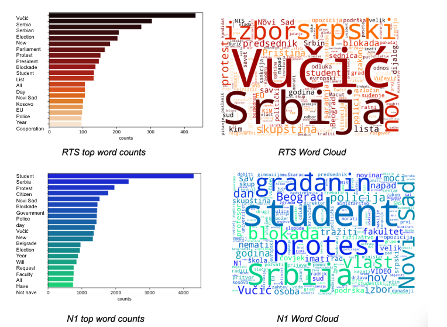

*Figure 2: Top Words*

Based on the results it can be seen that RTS's main focus in the news articles is on the president, elections, and parliament. The words related to the protest only come after the words such as the president's surname, and election.

In contrast N1's top word was student referring to the student porotest in Serbia, followed by the word Serbia, protest, citizen, Novi Sad which is the name of the city where the train station incident occurred and the protests started. The words related to the government, president, and election come after the protest related words.

These results are to be expected considering that RTS is government's news chanel and its main focus is on the government and the president in comparison to N1's main focus on the citizens and student protests.

https://colab.research.google.com/drive/1NuM0ofCdAd9Y6Fn-ADwmCTfFbEvhloNw?usp=sharing

## Frequency of Protest Related Articles

In order to compare the frequency of protest related articles over months it is important to initially determine which articles are related and which are unrelated to the protests.

To do this I used xlm-roberta-large-xnli model for zero-shot text classification

[https://huggingface.co/joeddav/xlm-roberta-large-xnli]

The sequence I used for classification was "This article is {}" (but in Serbian)

with the candidate labels being ["related to the protests", "unrelated to the protest"]

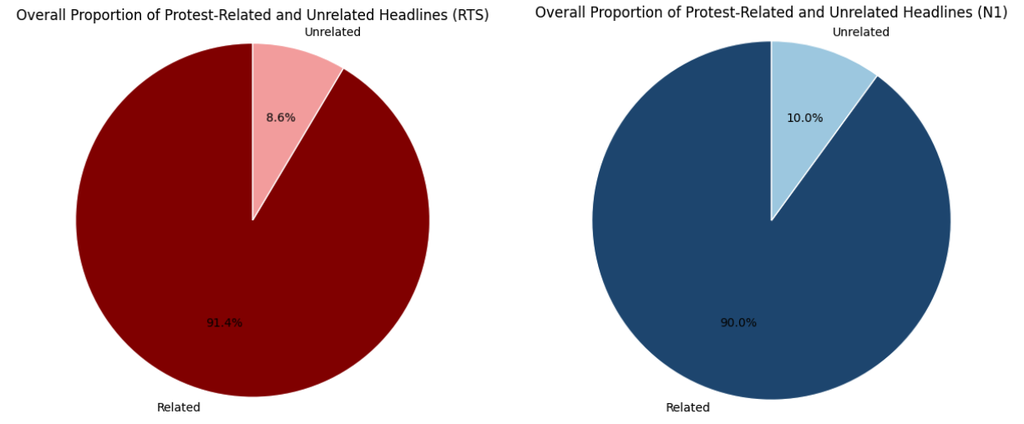

*Figure 3: Roberta Transformer Results Pie Chart*

What I found was that the majority of headlines were classified as related to the protests which matched my intuition considering that in this timeframe most events happening in Serbian politics were implicitly or explicitly related to the protests.

```
          precision    recall  f1-score   support

 RELATED       0.83      0.90      0.87       472
 UNCERTAIN     0.00      0.00      0.00        10
 UNRELATED     0.29      0.21      0.24        96

 accuracy                          0.77       578
 macro avg     0.37      0.37      0.37       578
 weighted avg  0.73      0.77      0.75       578
```

After comparing my labels to the roberta classified labels I found that while the model matched my interpertation of the headlines related to the protest it did not match my unrelated label. Reasons for this issue could be that the sample size of unrelated headlines I was checking was too small and also it could be that I have mistakenly labeled some headlines as related even though they were supposed to be unrelated as I interpreted that they were implicitly related to the protest.

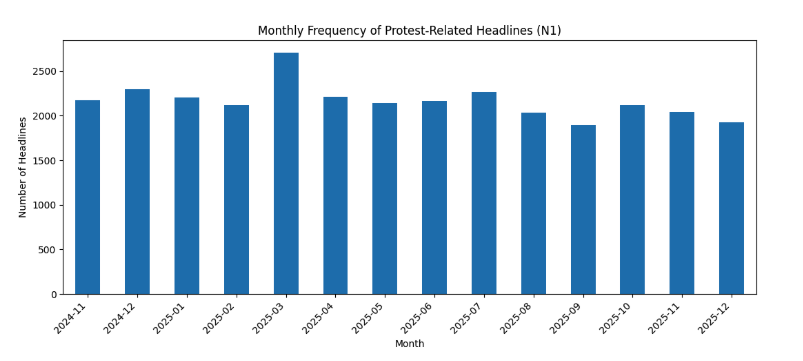

*Figure 4: N1 protest headline frequency*

After plotting the number of headlines classified as related in each month it can be seen that N1 published significantly more headlines in March 2025.

This could be related to the big protest which occured on March 15th in Belgrade which resulted in a large number of articles published around this date. It was reported that between 275 000 and 325 000 people attended this protest https://www.bbc.com/news/articles/cx2g8v32q30o.

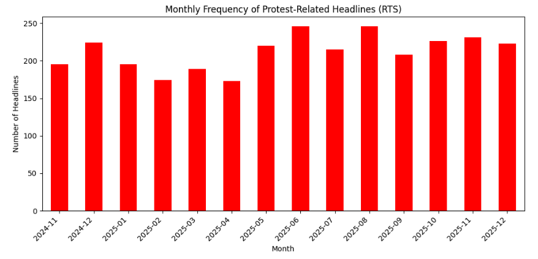

*Figure 5: RTS Protest Headline Frequency*

In comparison to N1 RTS shows a different trend. There was not a big spike in March 2025 like on N1. Instead, the number of protest Related headlines on RTS increased in Summer 2025. This could be related to the wave of protests that started after a big protest on June 28th 2025 which were characterized by the increased violence on protests.

## Event Extraction

In order to analyze what the different news channels in Serbia were reporting on during the protesting months I used Open AI's GPT API to perform the event extraction. I did this by sending each headline into an API prompt asking for it to be classified into differnet event categories.

Event categories I used:

- protest
- traffic_blockade
- institutional_blockade
- march_walk
- commemoration
- strike_boycott
- clash_police_action
- arrest
- investigation_charges_trial
- resignation
- government_response_policy
- counter_protest
- international_reaction
- election
- school_closure
- injury_death
- university_administration_action
- other

To come up with event categories I used ChatGpt to suggest me which categories would GPT API be good for the event extraction. However, some of the categories it gave me were too complicated so I simplified them into more simple event categories.

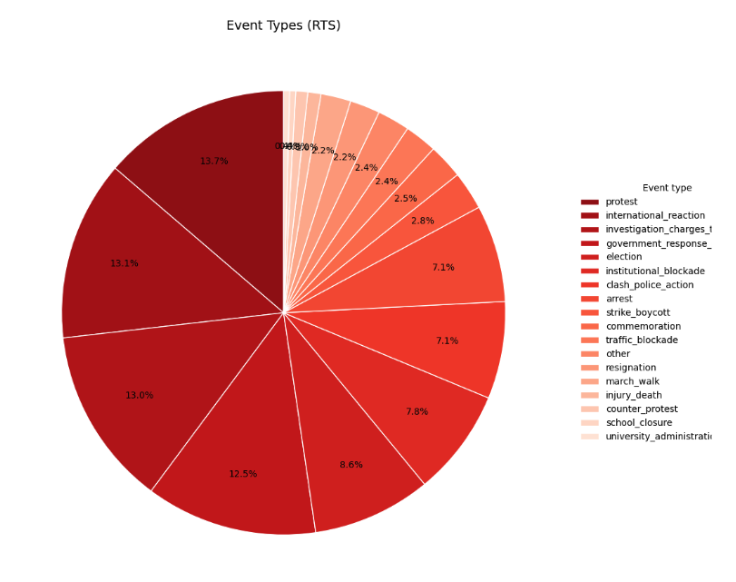

*Figure 6: RTS Headline Events Pie Chart*

GPT model I used was gpt-4o. After calling GPT API the most common event types in the RTS dataset were protest, international reaction, investigation charges trial, government responce policy, election...

THis matches with RTS's focus on the government actions and the international relations of the government which shows why international reacition is one of the top categories. Election is also one of the top events which is interesting because election category is one of the less common event types by N1.

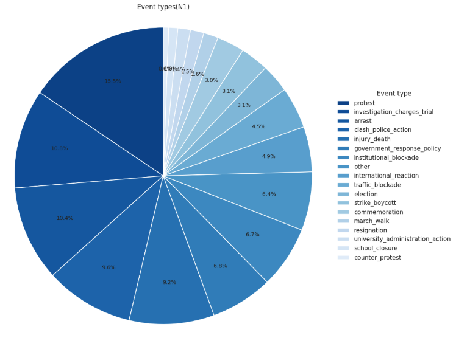

*Figure 7: N1 Headline Events Pie Chart*

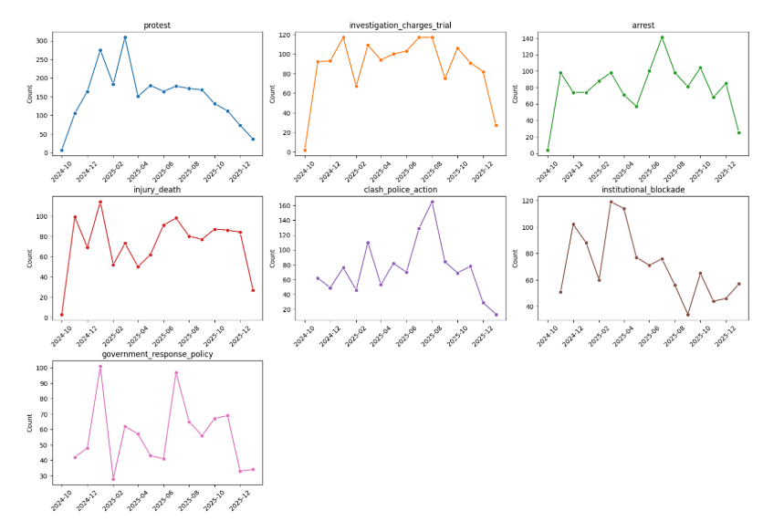

*Figure 8: N1 Headline Events Over Months*

**protest** the protest headlines reached their peak in March 2025 which correspons to the big protest on March 15th and in general the protests aare at thheir highest values at the beginning of the protesting movement and then they decrease after March 2025. This makes sense as it follows the general protesting trend which keeps decreasing since the start.

**investigation charges trial** has a constant trend with ocasional increases and drops with a decrease at the end of 2025. This correspons to one of the aspects of the protests which was that students were requestion an investigation on the files related to the rennovation of the train station. However, this all drops with the decrease in the overall protests.

**arrests** and **clash police action** follow the similar trend. They ignificantly increased in summer following a big protest on June 28th which sparked an increase of violence between protestors and the police and it resulted in the increase of arrests.

**institutional blockades** were highest at the beginning of the protests with their decrease later. This corresponds to the large number of institutional blockades that were happening such as university and school blockades which decreased in the later months of 2025.

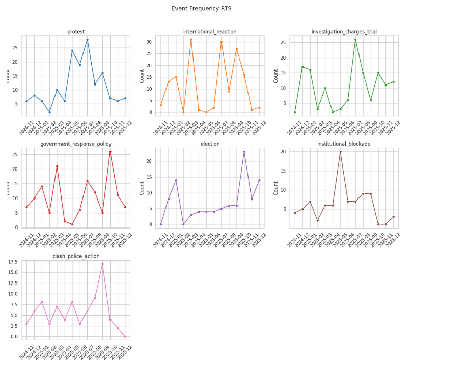

*Figure 9: RTS Headline Events Over Months*

**protest** In comparison to N1 protests had their peak in summer 2025 which wass when the violence in protests increased.

**international reaction** it is intersting to see that RTS is more concerned with the international reaction to the protests and these reports were high both at the start of 2025 when there was a large number of protests and in summer 20225 when violence at protests increased.

**election** RTS reports more on election and specifically this spike in election reports in the end of 2025 correspond to the elections in Kosovo.

https://colab.research.google.com/drive/11yzPaqdQ14JLSmm-tdyXfLOKNUvujOnZ?usp=sharing

## Conclusion

This project compared how two Serbian news channels N1 and RTS reported on the student protests that began after the Novi Sad railway station canopy collapse in November 2024.

I used web scraped headlines from November 2024 to December 2025. After analyzing the used vocabulary, frequency of protest related headlines over months, and different events discussed in the headlines I found some common characteristics of the two news channels.

N1’s most frequent words and event categories suggest a strong focus on the students and citizens and protests as well and also meniton arrests and clashes with the police. In comparison RTS focuses more on the government related issues, and talks more baou the international reaction to the protests, as well as the elections.

### Possible future steps

Great additions to this project which would make it more comprehensive could include:

1. Analyzing and comparing the sentiment of the headlines classified with and event type related to the protests. Both RTS and N1 have protests as their top event category but it would be interesting to see if the headlines tend to carry different sentiments towards the protests
2. Including both headlines and body text of the article. I have extracted the full text of all of the articles using the urls I have gathered initially but I haven't used it in my analysis. This data could be interesting in the future for further analyzing the vocabulary used by the two news channels and other tasks.
3. it would be interesting to see the difference in actors for events as as extracted by GPT API. When the API performed event extraction it also contained information on the actors. This could be interested for analysis to see how the different news channels referr to the actors in the protests as I have often noticed that in the headlines N1 would call the protestors "citizens" while RTS would call them "blockaders"

## References

Al Jazeera, Staff. “Thousands Rally in Serbia as Students Continue Fight against Corruption.” Al Jazeera, 18 Jan. 2026, www.aljazeera.com/news/2026/1/18/thousands-rally-in-serbia-as-students-continue-fight-against-corruption.

Delauney, Guy. Anger Lingers in Serbia a Year after Train Station Tragedy. 1 Nov. 2025, www.bbc.com/news/articles/ckgkk841r4eo.

DeLauney, Guy. “Fury at Novi Sad Station Tragedy Prompts Serbia to Make First Arrests.” BBC, 22 Nov. 2024, www.bbc.com/news/articles/c0qdyg8yn5yo.

Kleut, Jelena. Mapping Disinformation in the Serbian Media. Research report, Center for Research, Transparency and Accountability (CRTA), 2022, https://crta.rs/wp-content/uploads/2023/01/Mapping-disinformation-in-Serbian-media_2020.pdf.

Moench, Mallory. Fourteen Dead in Novi Sad, Serbia Railway Station Canopy Collapse. 1 Nov. 2024, www.bbc.com/news/articles/c9wrp7g05xro.

Stanicek, Branislav. At a Glance. www.europarl.europa.eu/RegData/etudes/ATAG/2025/775906/EPRS_ATA%282025%29775906_EN.pdf.

Use of OpenAI API for Event Extraction and ChatGPT for event extraction help